# Genetic diversity practical

Chloe Schmidt

2023-04-24

## Part 1: Working with genetic data in R

##### Brief intro to making maps, genind objects, visualizing population structure, and estimating diversity metrics

```r
# Libraries -----
library(sf)                # spatial data wrangling
library(rnaturalearth)     # optional; for base map
library(rnaturalearthdata) # optional; for base map
library(ggplot2)           # optional for mapping

library(adegenet)          # compute diversity metrics for genetic data
library(hierfstat)         # compute diversity metrics for genetic data

# Some extra custom functions:
source('other_functions.R')
```

### Load the data

Microsatellite genotypes and locations for snowshoe hare sampled across their geographic distribution

Data is from: Cheng et al. (2014) “Conservation implications of the evolutionary history and genetic diversity hotspots of the snowshoe hare.” Molecular Ecology 23(12): 2929-2942.

paper: https://onlinelibrary.wiley.com/doi/full/10.1111/mec.12790

data: https://datadryad.org/stash/dataset/doi:10.5061/dryad.dh63p

```r
microsats <- read.table('data/Cheng_Lepus_americanus.str')
coordinates <- read.csv('data/Lepus_americanus_coordinates.csv', header = TRUE)

# Overview of the data:
head(microsats)
```

```
##          V1  V2  V3  V4  V5 V6 V7  V8  V9 V10 V11 V12 V13 V14 V15 V16 V17
## 1 Cheng_AK2 107 113 216 216 75 81 107 127 192 194 114 116  93 107 231 240
## 2 Cheng_AK2 105 120 216 218 77 79 107 127 192 192 116 116 105 109 231 248
## 3 Cheng_AK2 105 117 211 213 79 79 107 107 192 194 116 116 103 109 234 238
## 4 Cheng_AK2 107 123 211 216 79 79 107 123 192 192 116 116  95  95 220 236
## 5 Cheng_AK2 119 123 211 211 79 79 107 123 192 196 114 116  95  95 232 236
## 6 Cheng_AK2 119 123 216 218 79 79 107 107 188 192 116 116 101 103 240 240
```

```r
head(coordinates)
```

```
##         pop       lon      lat
## 1 Cheng_AB1 -114.0025 52.81244
## 2 Cheng_AB2 -115.1558 55.58100
## 3 Cheng_AK2 -147.6671 64.41532
## 4 Cheng_AK4 -162.4235 67.04434
## 5 Cheng_AK6 -145.3133 61.97933
## 6 Cheng_BC1 -122.9749 49.27093
```

### 1. Mapping samples

We can simply plot the data like this to get an idea:

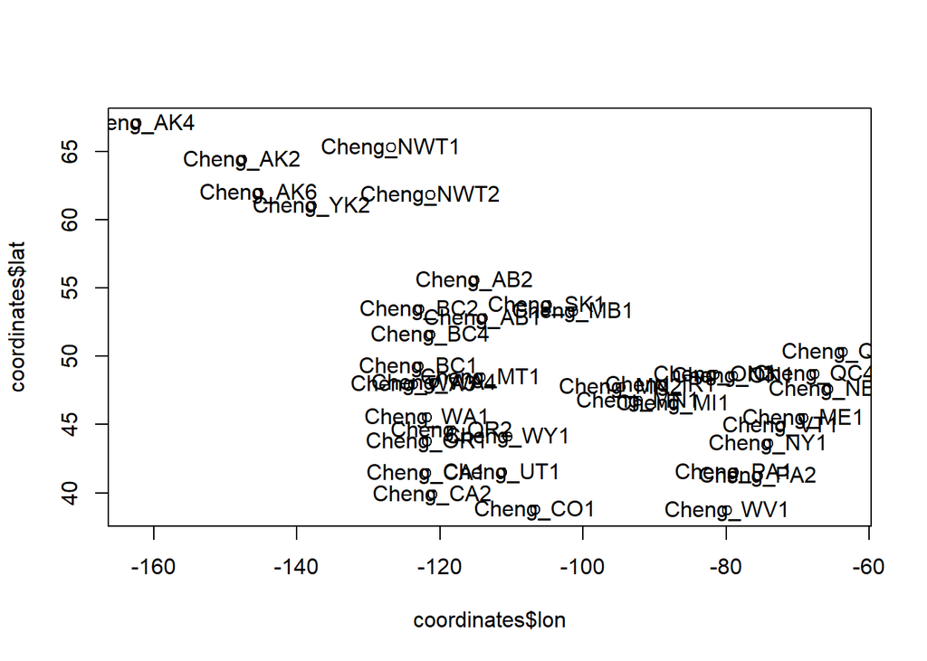

```r
plot(coordinates$lon, coordinates$lat)
text(coordinates$lon, coordinates$lat, labels = coordinates$pop)
```

But, we might want to make a nicer map to understand the spatial context of where these points are.

Feel free to run this code if you wish (will require additional packages)– This section is optional!

We’ll start by telling R that the coordinates are spatial locations. The coordinates are from GPS, and use the ‘WGS84’ coordinate reference system (crs), where units are decimal degrees

The sf package uses codes for coordinate reference systems from the EPSG: https://epsg.io/

More on coordinate systems: https://www.nceas.ucsb.edu/sites/default/files/2020-04/OverviewCoordinateReferenceSystems.pdf

```r
coords_spatial <- st_as_sf(coordinates, coords = c('lon', 'lat'), crs = 4326)

head(coords_spatial)
```

```
## Simple feature collection with 6 features and 1 field
## Geometry type: POINT
## Dimension:     XY
## Bounding box:  xmin: -162.4235 ymin: 49.27093 xmax: -114.0025 ymax: 67.04434
## Geodetic CRS:  WGS 84
##         pop                   geometry
## 1 Cheng_AB1 POINT (-114.0025 52.81244)
## 2 Cheng_AB2   POINT (-115.1558 55.581)
## 3 Cheng_AK2 POINT (-147.6671 64.41532)
## 4 Cheng_AK4 POINT (-162.4235 67.04434)
## 5 Cheng_AK6 POINT (-145.3133 61.97933)
## 6 Cheng_BC1 POINT (-122.9749 49.27093)
```

*Q: How did the coordinate data change? What does it look like now?*

These data were sampled in Canada and the US. Let’s get a map of these countries:

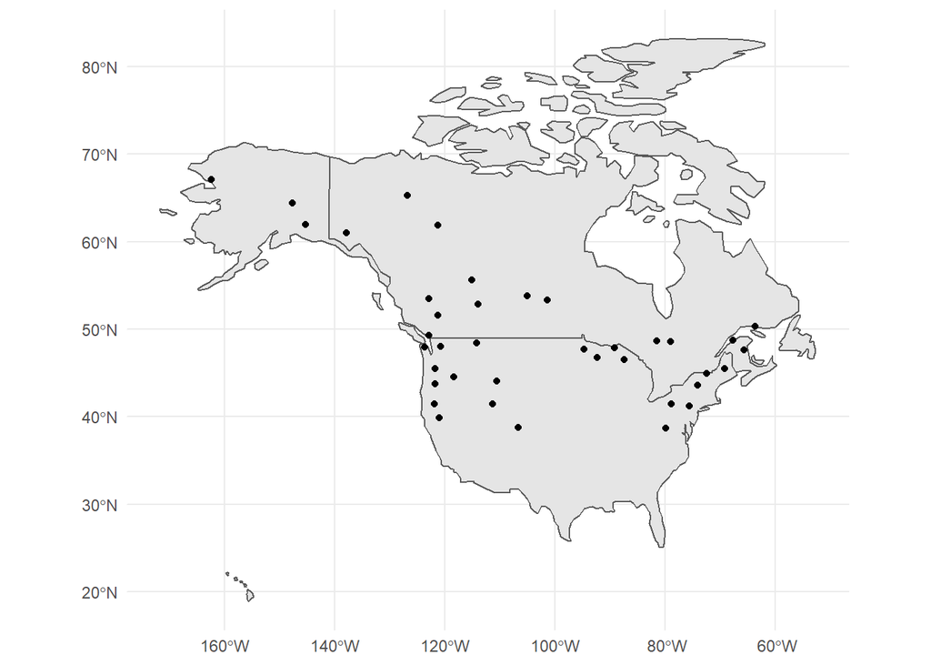

```r
ca_usa <- ne_countries(country = c('Canada', 'United States of America'), returnclass = 'sf')

# Plot with ggplot:
ggplot() +
  geom_sf(data = ca_usa) +
  geom_sf(data = coords_spatial) +
  theme_minimal()
```

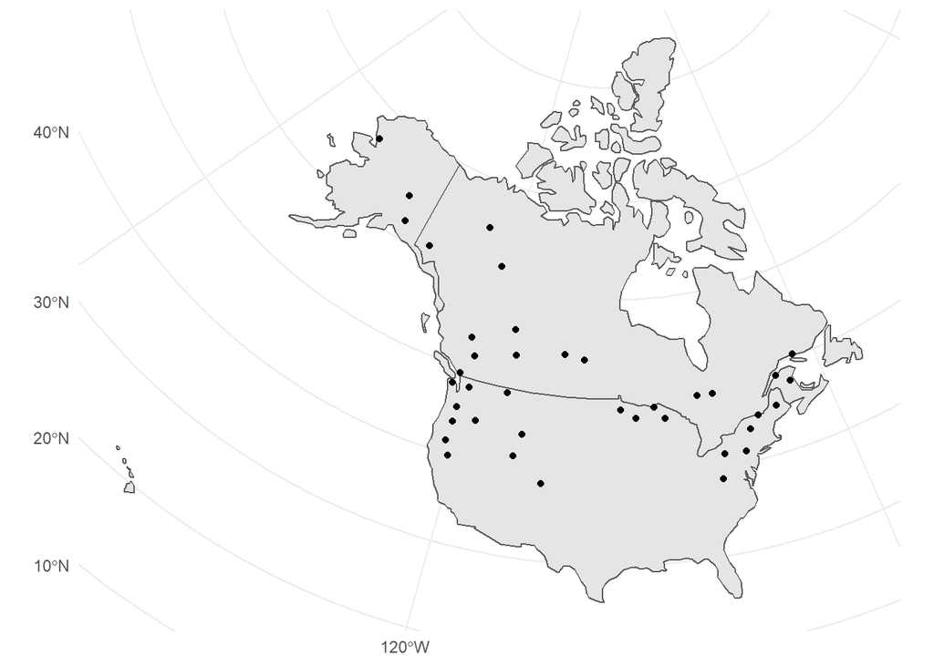

```r
# And in a nicer projection so it's less distorted:
# coord_sf() transforms the data into a new coordinate system. This is a Lambert conformal conic projection for North America
ggplot() +
  geom_sf(data = ca_usa) +
  geom_sf(data = coords_spatial) +
  coord_sf(crs = 'ESRI:102009') +
  theme_minimal()
```

### 2. Exploring a microsatellite dataset

These data are formatted in a file type (str) for a software called STRUCTURE. Rows are individuals, the first column is a group ID, and the rest of the columns are alleles.

Snowshoe hare are diploid (two copies of each chromosome), so each locus has 2 columns. The data can be formatted with one individual per row, and each column is every allele of every locus (Locus 1 allele 1; locus 1 allele 2; locus 2 allele 1, etc.)

OR, the data can have each individual on two rows, where one row is allele 1, and the second row is allele 2, and each column is one locus.

In this file, individuals are on one row, and the groups are sample locations.

**Q1: how many individuals are there in this file?**

```r
# Hint:
# nrow(microsats)
```

**Q2: how many loci are there in this file?**

```r
# Hint:
# ncol(microsats)
```

Now we want R to read the file knowing that it’s genetic data. We use the function read.structure() for this:

```r
snow <- read.structure('data/Cheng_Lepus_americanus.str')
```

What happened? Did it work?

We need to provide more info about the samples before loading the data.

Read the data in:

```r
snow <- read.structure('data/Cheng_Lepus_americanus.str',         # file
                               n.ind = nrow(microsats),           # number of individuals
                               n.loc = (ncol(microsats)-1)/2,     # number of loci
                               onerowperind = TRUE,               # one individual per row
                               col.pop = 1,                       # population ID is the 1st column
                               ask = FALSE)                       # won't ask you questions :)
```

```
##
##  Converting data from a STRUCTURE .stru file to a genind object...
```

```r
snow # This is now a 'genind' object
```

```
## /// GENIND OBJECT /////////
##
##  // 853 individuals; 8 loci; 185 alleles; size: 711 Kb
##
##  // Basic content
##    @tab:  853 x 185 matrix of allele counts
##    @loc.n.all: number of alleles per locus (range: 10-42)
##    @loc.fac: locus factor for the 185 columns of @tab
##    @all.names: list of allele names for each locus
##    @ploidy: ploidy of each individual  (range: 2-2)
##    @type:  codom
##    @call: read.structure(file = "data/Cheng_Lepus_americanus.str", n.ind = nrow(microsats),
##     n.loc = (ncol(microsats) - 1)/2, onerowperind = TRUE, col.pop = 1,
##     ask = FALSE)
##
##  // Optional content
##    @pop: population of each individual (group size range: 7-100)
```

```r
summary(snow)
```

```
##
## // Number of individuals: 853
## // Group sizes: 28 13 18 40 10 9 19 100 7 12 30 32 13 25 18 13 34 9 30 9 8 9 58 11 20 29 77 12 15 9 10 8 25 10 17 20 17 14 15
## // Number of alleles per locus: 31 15 10 15 39 19 14 42
## // Number of alleles per group: 60 53 61 78 42 52 74 97 29 39 74 72 54 39 69 52 77 56 68 38 49 41 62 56 72 75 58 60 46 38 47 52 63 45 56 68 47 36 34
## // Percentage of missing data: 0.18 %
## // Observed heterozygosity: 0.82 0.5 0.47 0.59 0.61 0.49 0.7 0.83
## // Expected heterozygosity: 0.94 0.86 0.73 0.8 0.83 0.65 0.85 0.96
```

What’s stored in a genind object?

```r
attributes(snow)
```

$tab is the part that stores the counts for each allele which are used to compute diversity metrics

#### Visualize at population structure

Sample sites are not necessarily separate “populations.” The goal of studies is often to describe *population structure* by clustering locations with similar genetic makeup (similar allele frequencies) indicating that they likely make up a single population.

We can get a rough idea about population structure by doing a quick principal components analysis (PCA) on the allele frequency data:

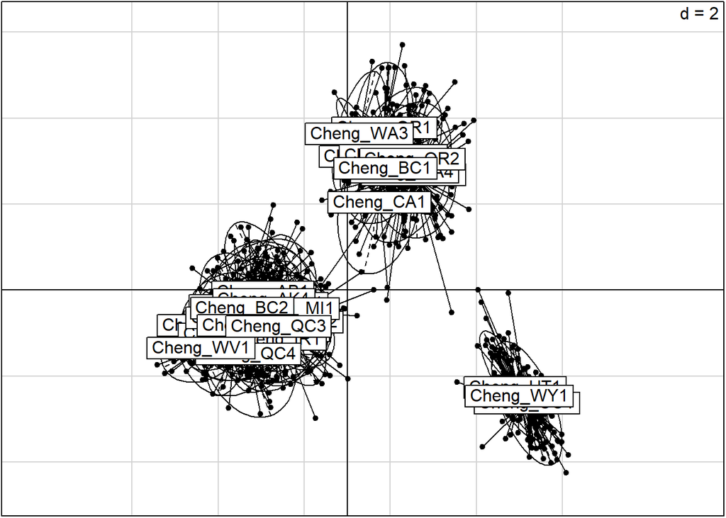

```r
X <- scaleGen(snow, NA.method = "mean") # scale and center the data; tell it how to handle missing values
pcaX <- dudi.pca(X, scannf=FALSE, scale= F, center = F) # PCA analysis
s.class(pcaX$li, pop(snow)) # plot PCA results
```

**Q3: What do you see? Describe the population structure of snowshoe hare.**

##### Optional if you have ggplot and the basemap loaded

Populations are generally not so rigid as clustering will suggest. They can be quite arbitrary and depend on what the research question is.

Looking at higher or lower levels of clustering can help understand the data. Try plotting with different numbers of clusters (k):

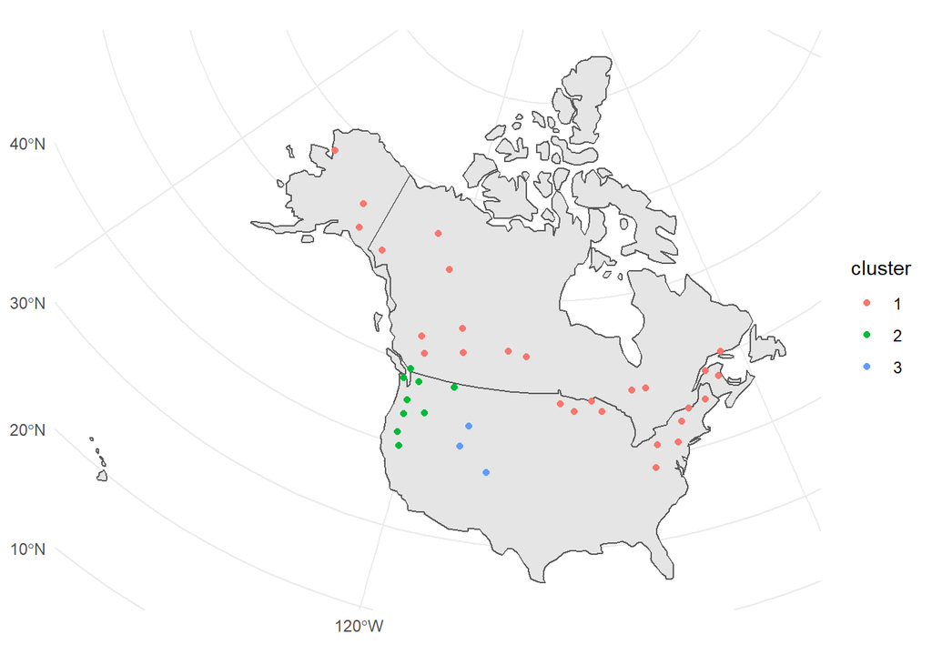

```r
plot_clusters(data = snow, sf_data = coords_spatial, clusters = 3)
```

### 3. Estimating diversity metrics (alpha diversity)

We can estimate the genetic diversity at each site in several ways. Here we’ll use two: allelic richness and gene diversity.

#### 3a. Allelic richness

Allelic richness is the total number of alleles at each site.

We can see this in the summary of the genind object:

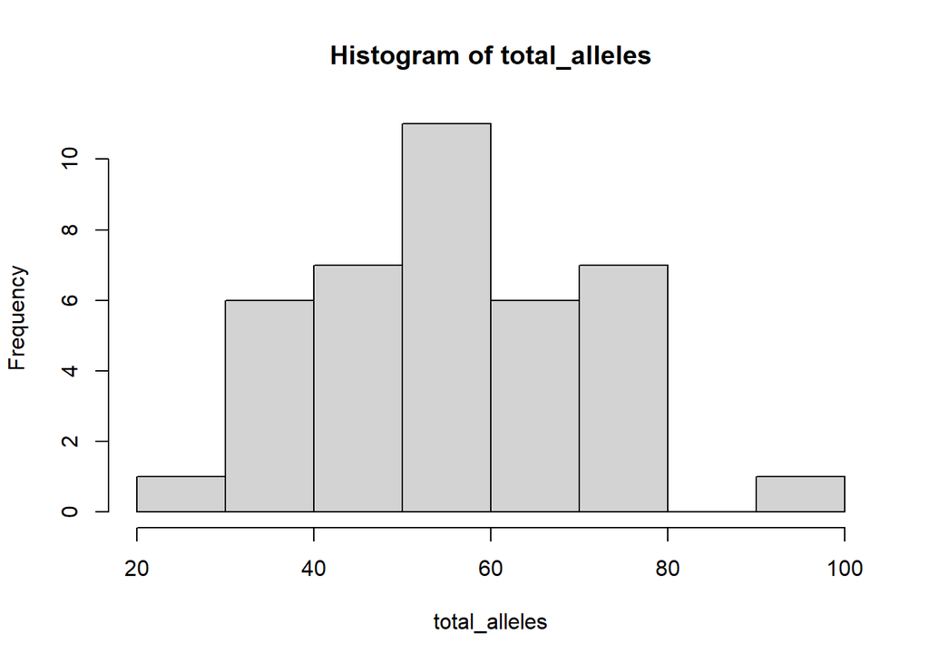

```r
s.snow <- summary(snow)
total_alleles <- s.snow$pop.n.all

hist(total_alleles)
```

Let’s compare this to the number of individuals sampled at each site:

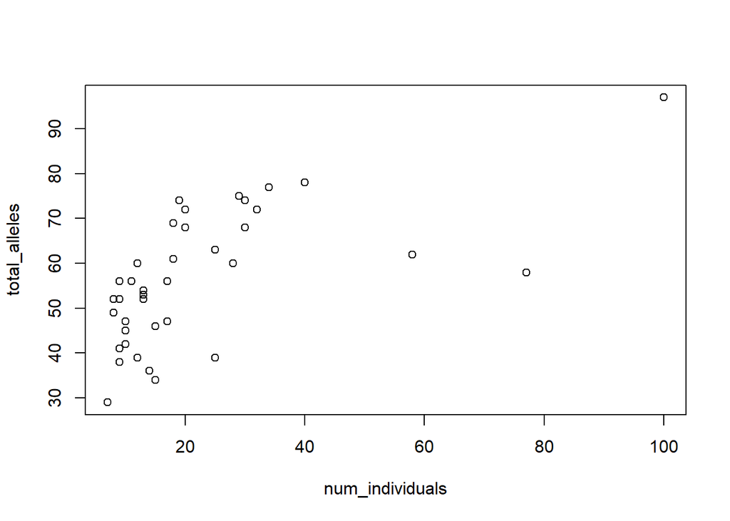

```r
num_individuals <- s.snow$n.by.pop

plot(total_alleles ~ num_individuals)
```

**Q4: What’s happening in this plot? How correlated are the numbers of alleles and numbers of samples?**

```r
cor.test(total_alleles, num_individuals)
```

In general, allelic richness is not a good measure of genetic diversity unless sample sizes are equal.

We will use rarefaction to standardize this value according to sample size.

```r
# min.n is the lowest number of alleles sampled in a population.
ar_hares <- allelic.richness(snow, min.n = 14)
```

This is the default value. The smallest sample size is 7 individuals (=14 alleles)

We can take the mean richness across all loci to get 1 estimate for the population:

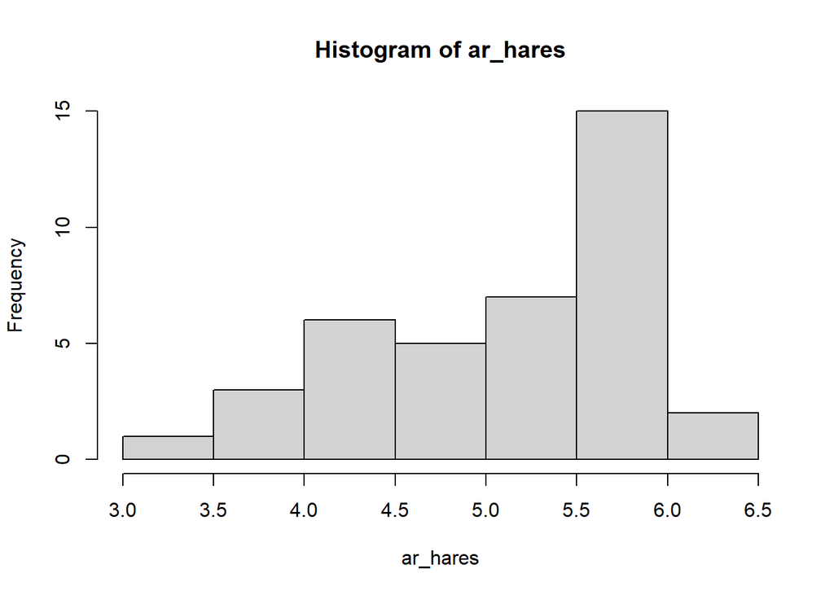

```r
ar_hares <- colMeans(ar_hares$Ar)
hist(ar_hares)
```

Now let’s see the relationship with sample size:

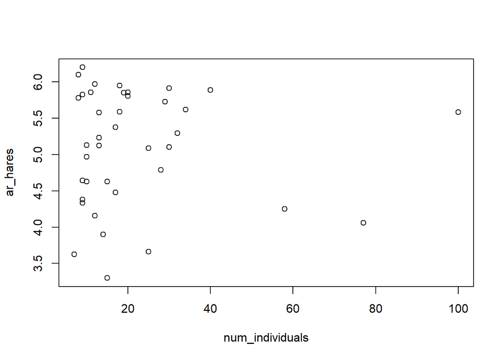

```r
plot(ar_hares ~ num_individuals)
```

```r
cor.test(ar_hares, num_individuals)
```

**Q5: what happens if you change the minimum sample size?**

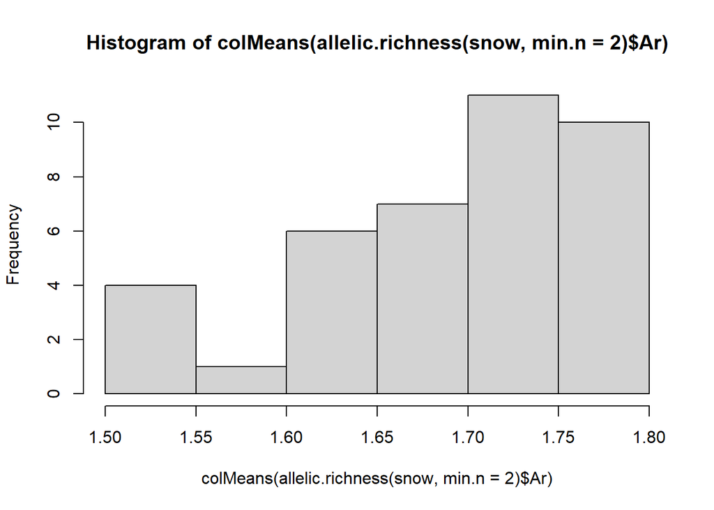

```r
hist(colMeans(allelic.richness(snow, min.n = 2)$Ar))
```

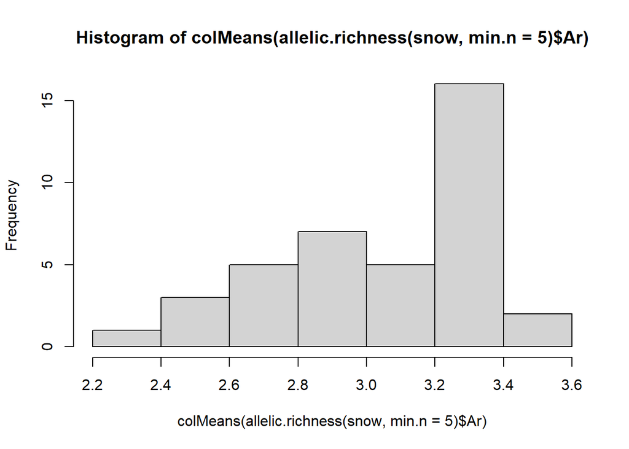

```r
hist(colMeans(allelic.richness(snow, min.n = 5)$Ar))
```

#### 3b. Gene diversity

Gene diversity is the probability of choosing two alleles that are different from the population.

This is a metric of diversity based on *evenness*: it is highest when all alleles have the same frequency.

Gene diversity varies between 0 (low diversity) and 1 (high diversity).

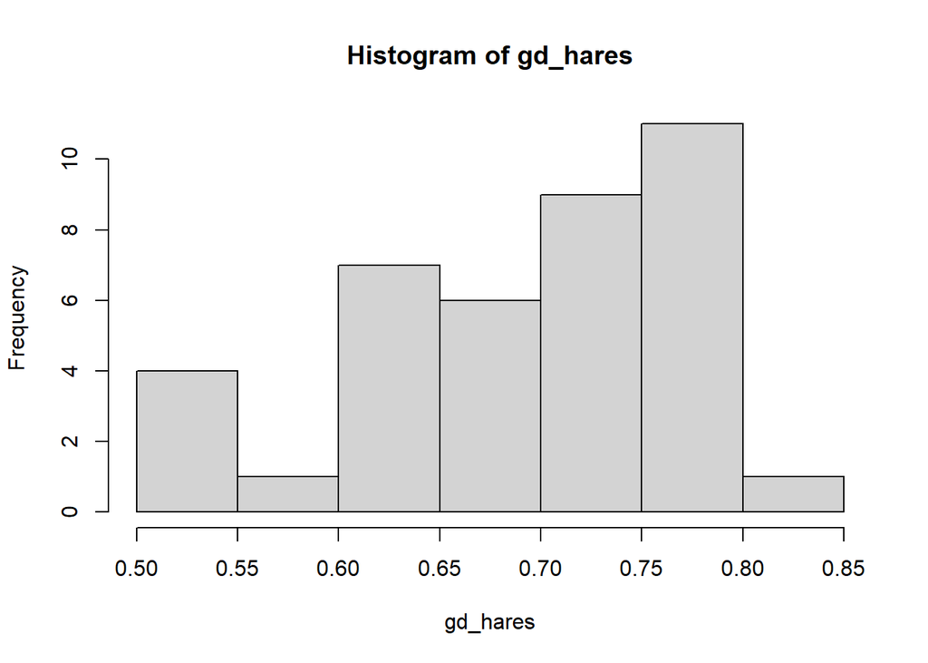

```r
gd_hares <- Hs(snow)
hist(gd_hares)
```

How is gene diversity related to sample size?

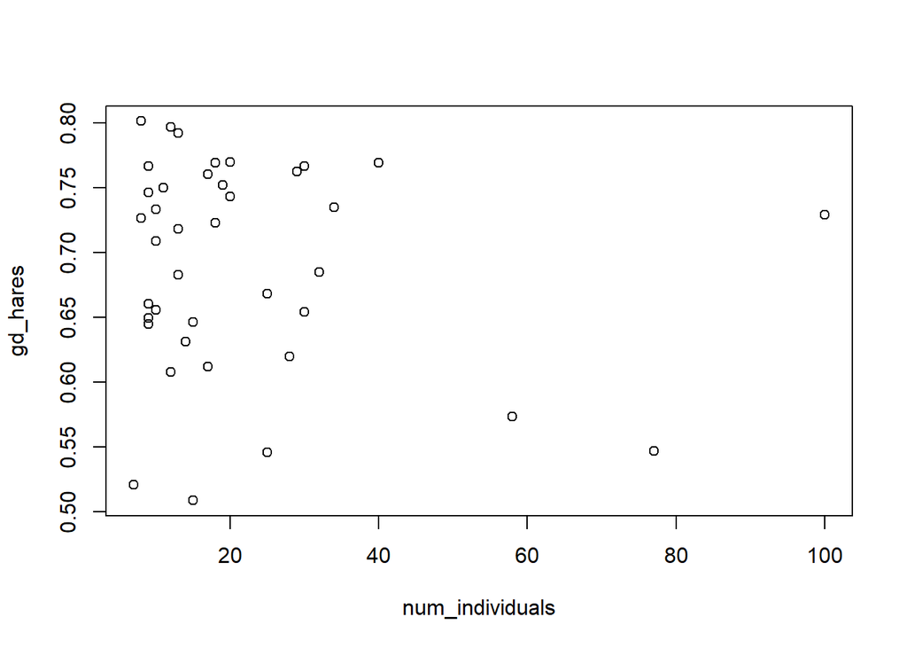

```r
plot(gd_hares~num_individuals)
```

```r
cor.test(gd_hares, num_individuals)
```

**Q6: How is the gene diversity of these hares?**

Compare allelic richness and gene diversity:

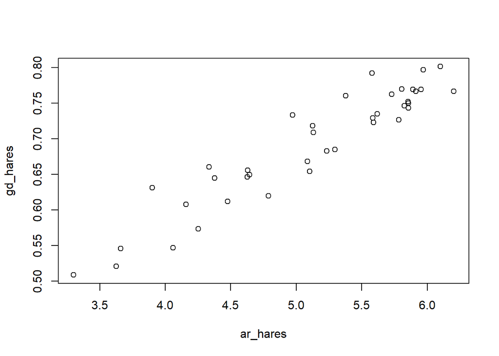

```r
plot(gd_hares~ar_hares)
```

```r
cor.test(gd_hares, ar_hares)
```

```
##
##  Pearson's product-moment correlation
##
## data:  gd_hares and ar_hares
## t = 17.093, df = 37, p-value < 2.2e-16
## alternative hypothesis: true correlation is not equal to 0
## 95 percent confidence interval:
##  0.8916594 0.9694629
## sample estimates:
##       cor
## 0.9421249
```

### 4. Estimating differentiation metrics (beta diversity)

In population genetics we typically use FST to estimate genetic differentiation. This is based on Wright’s F-statistics, and it’s a way to partition variance in allele frequencies within populations vs between populations.

There are many flavors of FST. (Technically, the one we use for microsatellite data is called GST).

A common FST is pairwise FST developed by Weir & Cockerham (1984). With this, we compare all pairs of populations.

```r
snow_hst <- genind2hierfstat(snow)
pw_fst <- hierfstat::pairwise.WCfst(snow_hst) # this is a bit slow for bigger datasets
```

This gives us a matrix of pairwise differentiation where higher numbers indicate stronger differentiation.

**Q7. What are the NA values in the FST matrix?**

We can visualize pairwise FST using principal coordinates analysis (PCoA)

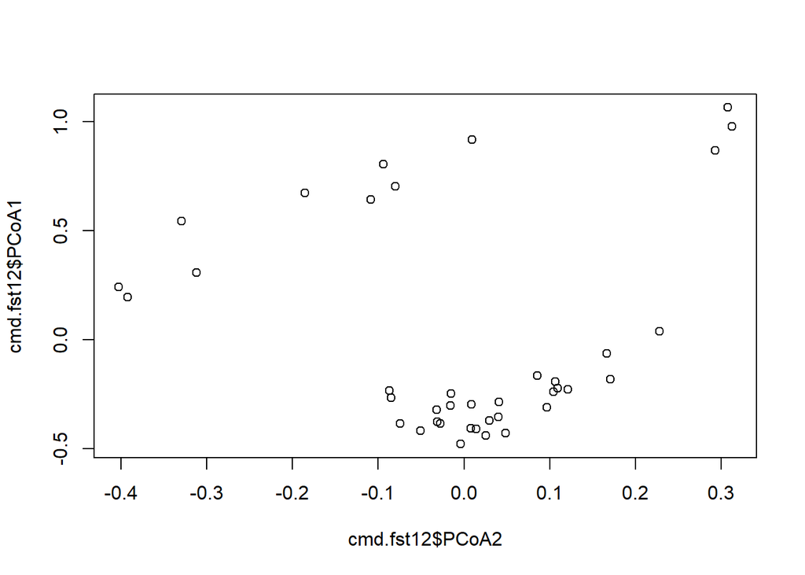

```r
cmd.pair.fst <- cmdscale(dist(pw_fst), k=3, eig=T)
cmd.fst <- cmd.pair.fst$points
cmd.fst12 <- data.frame(pop = rownames(cmd.fst),
                        PCoA1 = cmd.fst[,1],
                        PCoA2 = cmd.fst[,2])

plot(cmd.fst12$PCoA2, cmd.fst12$PCoA1)
```

**Q7: Does anything seem familiar in this plot?** Hint: population differentiation is a measure of population structure

Pairwise FST is useful, but sometimes for our analyses it’s simpler to have a single value per population.

And, especially when working with data from multiple species, comparing pairwise FST can be misleading due to the way it’s calculated.

We can overcome these issues using another metric of differentiation: population-specific FST. The interpretation of this metric is slightly different: it is an estimate of how far a population has diverged from the common ancestor of all the populations sampled.

```r
ps.fst <- betas(snow)
names(ps.fst)
```

```
## [1] "betaijT"  "Hi"       "Hb"       "betaiovl" "betaW"
```

```r
# Population-specific FSTs are stored in 'betaiovl'
ps.fst <- ps.fst$betaiovl
summary(ps.fst)
```

```
##    Min. 1st Qu.  Median    Mean 3rd Qu.    Max.
## 0.02696 0.07777 0.12814 0.15833 0.21360 0.38023
```

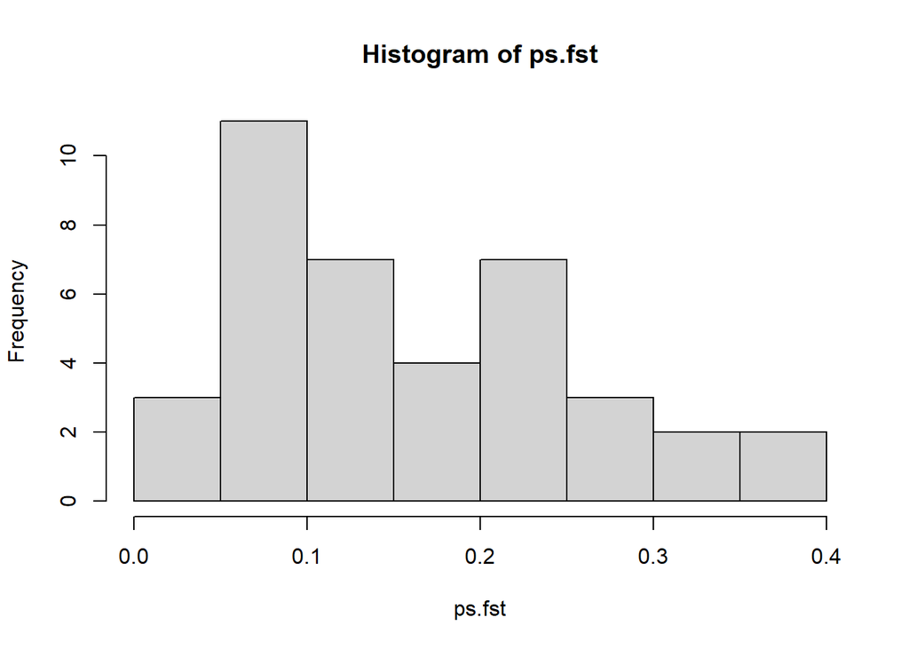

```r
hist(ps.fst)
```

Let’s plot these on the map!

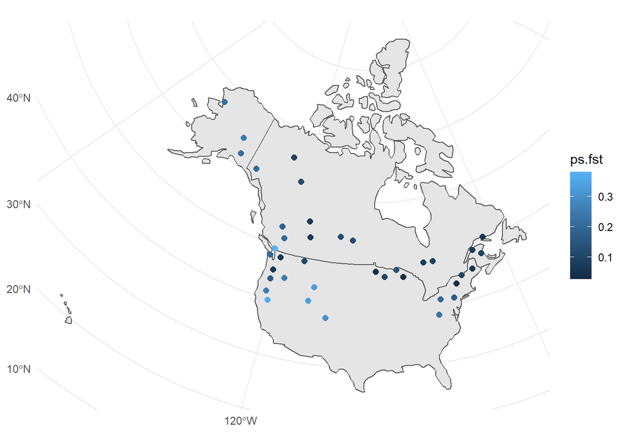

```r
coords_spatial$ps.fst <- ps.fst[order(names(ps.fst))] # populations are in alphabetical order in the coordinate data

ggplot() +
  geom_sf(data = ca_usa) +
  geom_sf(data = coords_spatial, aes(color = ps.fst), size = 2) +
  coord_sf(crs = 'ESRI:102009') +
  theme_minimal()
```

**Q8: Does this map make sense to you? Why or why not?**